# CS 372/472 & LRN_SCI 372/472

Verification and Validation

Prof. Connor Bain

connor.bain@northwestern.edu

May 26, 2026

## Logistical Stuff

**Final Project Update 2**

- You’ll receive feedback from me on your first update by the end of the day on May 27th.
- Due on Sunday May 31st at 11:59pm!

**Final Projects Deadline Quickly Approaching.**

- Presentations will be on June 2nd and June 4th (we will assign presentation dates in class on May 28th).
- Paper, Model, Video Walkthrough, and Virtual Poster are due on June 11th at 5pm.
- Details on Canvas

## Model towards a question

> “The word model sounds more scientific than the word fable or tale, but I think we are talking about the same thing.” - Ariel Rubinstein
- How do we tell if we designed something useful?
- How do we tell if we designed what we meant to?
- **Analysis** - what does our model allow us to explore?
- **Verification** - did we build the model right?
- **Validation** - did we build the right model?

## How do we ask questions of models?

Let’s take a look at the `Spread of Disease` model in NetLogo.

- What questions could we ask of this model?
- How would we go about answering those questions?
- What sort of experiments can we conduct? And how?

## Model Correctness

- **Verification**: Does an implemented model correspond to the target conceptual model?
- **Validation**: Does the implemented model correspond to and explain some phenomenon in the real world?
- **Replication**: Can we reimplement a model from its conceptual model and get the same results?

## Model Replication

### Replication Standards

- Numerical identity
- Statistical equivalence
- Relational alignment

> **Subtle differences can matter!** For instance, you might have differences based off of different random number generators or even strange floating point rounding issues.

## Model Verification

> **Does an implemented model correspond to the target conceptual model?**

Imagine that we are approached by a group of political scientists who want to develop a simple model of voting behavior. They explain that they think that people’s social interactions largely determine voting in elections. Based on their observations of polls and election results, they think that people have some initial way that they want to vote, and when they are initially polled they express those feelings. However, between the times when they are polled they talk to their neighbors and colleagues and discuss the way they plan to vote; this may change the way they decide to vote. In fact, this may happen several times during the period leading up to an election. The political scientists ask us to build an ABM of this concept.

## Expected outcomes

- Some of them say their expectation is that regions of voters will develop with sharp boundaries.
- Others think one set of voters might dominate.

# How would you design a model like this?

## Model Design

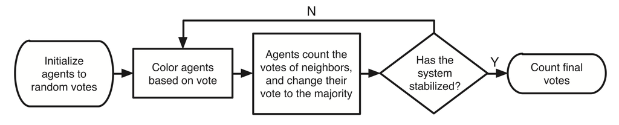

Initial Model Design

## Initial Implementation

- Let’s take a look at the initial implementation of this model in NetLogo and see if it matches your ideas.

## Unit Testing

```
to check-setup
  let diff abs ( count patches with [ pcolor = green ] - count patches with [ pcolor = blue ])
  if diff > .1 * count patches [
    print "Warning: Difference in initial greens vs blues is greater than 10%."
  ]
end
```

## Why don’t the model dynamics look like what they expected?

- What’s going on here? Is there a bug in the code? Or is there an unanticipated emergent effect that arises from the implemented model but was not anticipated in the conceptual model?

## Ways a Model Can Fail Verification

- Bugs in the code
- Gap between understanding of a conceptual model and code for the implemented model
- Unanticipated emergent effects that arise from the implemented model but were not anticipated in the conceptual model

## Methods of Analysis

- **Sensitivity Analysis**: an examination of the impact of varying model parameters on model results.
  - To determine how sensitive a model is, we examine the effect that different initial conditions and agent mechanisms have on the model results.

> Our political scientists wonder how much our result depends on the initial percentage of the population that votes for a particular candidate. If we vary the initial percentage of green voters, how will that affect our result?

## How do we make this happen?

1. Create a slider for the initial percentage of green voters.
2. Run an experiment where we vary the initial percentage of green voters and observe the resulting dynamics.

We have to make sure to control for other parts of the model!

## Design an Experiment

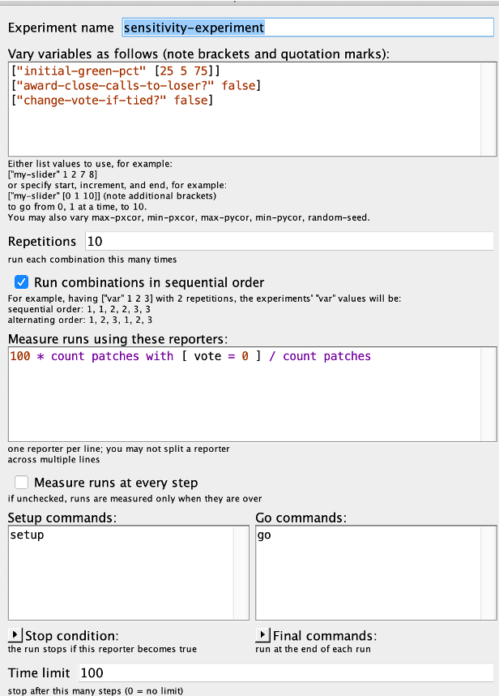

Experiment Design

## Outcomes

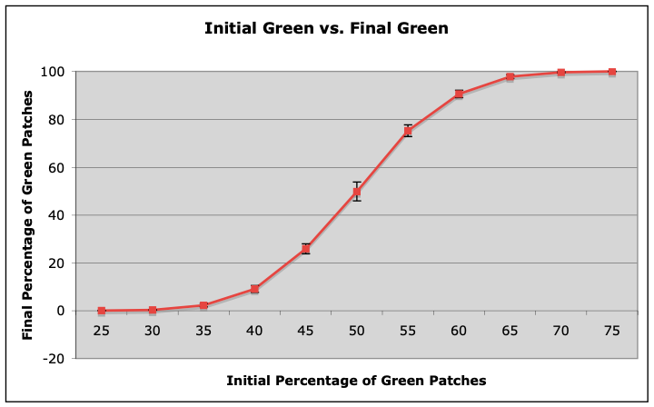

Experiment Outcome

## Model Validation

> **Does an implemented model correspond to the modeled phenomenon in the real world?**

## Flocking Boids

Based on Reynolds (1987)

The birds (“boids”) follow three rules

- Separation – If I get to close to another bird, I try to turn to avoid hitting it, and don’t bother with the other two rules
- Alignment – I try to face the same direction as nearby birds
- Cohesion – I try to turn to stay close to those around me

The three rules affect only the bird’s heading. Each bird always moves forward.

## Axes of Validation

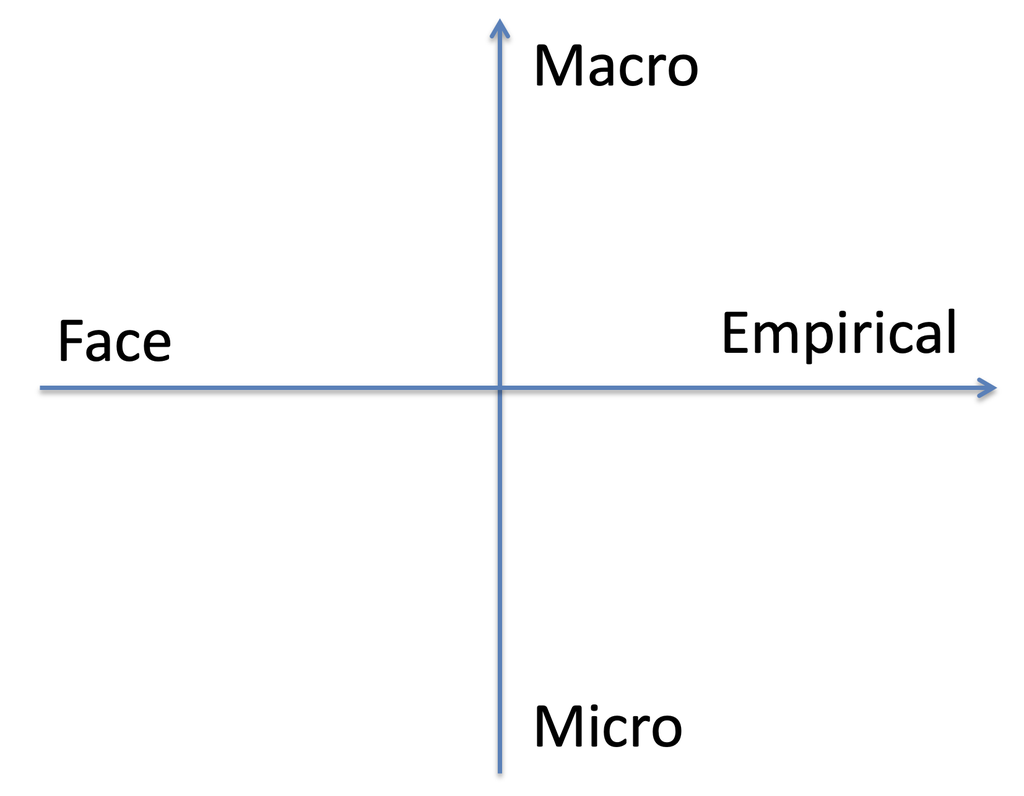

Axes of Validation

## References

Reynolds, Craig W. 1987. “Flocks, Herds and Schools: A Distributed Behavioral Model.” *Proceedings of the 14th Annual Conference on Computer Graphics and Interactive Techniques*, 25–34.